# Assignment_PracticalML

DR

3 April 2016

## Synopsis

The goal of this assignment is to assess how well exercise has been done rather than how much. Data has been collected from accelerometers on the belt, forearm, arm and dumbell of 6 people, who have been asked to do barbell lifts correctly and incorrectly in five different ways.

The key findings are: * Random forests have a 97% accuracy in predicting on the cross validation test suite. * Random forests are better than the other models considered: namely decision trees (rpart) and generalised boosted linear models (gbm). * One should take care in overinterpretting this result as they are from only 6 participants in the experiment. * 19 of the 20 test points were predicted correctly with the fitted model.

## Required libraries

```r
library(caret) # required for the machine learning
```

```r
library(rpart)
library(rpart.plot);library(rattle) # for nice plots of classification trees
library(dplyr) #useful for data frame manipulation
library(ElemStatLearn) #useful for bagging
library(randomForest)
library(AppliedPredictiveModeling) # to get the accuracy of the model fits using confusionMatrix
library(klaR) # for accuracy measure
```

## Data Processing – read in the data and then clean it

```r
if(!file.exists("pml_training.csv")){
  download.file("https://d396qusza40orc.cloudfront.net/predmachlearn/pml-training.csv","pml_training.csv")
}
if(!file.exists("pml_testing.csv")){
  download.file("https://d396qusza40orc.cloudfront.net/predmachlearn/pml-testing.csv","pml_testing.csv")
}
training<-read.csv("pml_training.csv",stringsAsFactors = FALSE,header=TRUE)
testing<-read.csv("pml_testing.csv",stringsAsFactors = FALSE,header=TRUE)

dim(training) # to get size of training data
```

```
## [1] 19622   160
```

```r
dim(testing) # to get size of training data
```

```
## [1]  20 160
```

The `training` data will be used to construct the model and will be subdivided into a training and testing set. In this context testing of the training data will be used for model selection. The best model as it performs on this subtesting set will be put forward on the actual testing set. For clarity I will refer to the `subtraining` and `subtesting` sets (as subparts of the training data set) and the testing set.

Now let’s have a look at the data and see if it needs to be cleaned (on the way let’s also have a look at the classe variable).

```r
#head(training)
#names(training)
table(training$classe)
```

```
##
##    A    B    C    D    E
## 5580 3797 3422 3216 3607
```

```r
table(is.na(training))
```

```
##
##   FALSE    TRUE
## 1852048 1287472
```

Many of the variables have NA values. Let’s eliminate the NA values, but first eliminate the column for the `classe` variable we’re trying to predict.

```r
# Now let's find those columns with a large number of NA values
proportion_NA <-sapply(training, function(y) sum(length(which(is.na(y))))/length(y))
```

```r
whichcols<-c(proportion_NA < 0.9)
training<- training[whichcols]
```

```r
training<-training[-c(1:7)]
dim(training)
```

```
## [1] 19622    86
```

The cleaning isn’t done yet. We also saw that there may be columns with lots of missing values. Let’s check for them by setting them to be NA. Then do the same steps as before to eliminate those columns.

```r
training[training==""]<-NA
proportion_NA <-sapply(training, function(y) sum(length(which(is.na(y))))/length(y))
whichcols<-c(proportion_NA < 0.9)
training<- training[whichcols]
dim(training)
```

```
## [1] 19622    53
```

## Creating the subtraining and subtesting sets. And then doing a PCA.

I have subsetted the (cleaned) training set with a 60/40 split between subtraining and subtesting sets. For reproducibility I specify the seed used.

```r
set.seed(1234)
train_choice<-createDataPartition(y=training$classe,p=0.6,list=FALSE)
subtraining<-training[train_choice,];subtesting<-training[-train_choice,]
dim(subtraining)
```

```
## [1] 11776    53
```

```r
dim(subtesting)
```

```
## [1] 7846   53
```

These data sets are pretty big so first I will do a **PCA** analysis to reduce this. I use a threshold of $95\%$ to capture as much of the information as possible. Be careful not to include the variable we’re trying to predict within the PCA

```r
preProc<-preProcess(subtraining[,-which(colnames(subtraining)=="classe")],method="pca",thresh=0.95)
subtrainingPCA<-predict(preProc,subtraining[,-which(colnames(subtraining)=="classe")])
subtestingPCA<-predict(preProc,subtesting[,-which(colnames(subtraining)=="classe")])
dim(subtrainingPCA)
```

```
## [1] 11776    24
```

```r
dim(subtestingPCA)
```

```
## [1] 7846   24
```

## Building the model (on the subtraining set)

As the goal of this model is to classify how well exercise has been done, I will try a selection of classification schemes: namely * classification/decision trees (rpart) * random forests (rf) * generalised boosted regression model (gbm)

```r
modFit_rpart<-suppressMessages(train(subtraining$classe~.,data=subtrainingPCA,method="rpart"))
#modFit_rf<-suppressMessages(train(subtraining$classe~.,data=subtrainingPCA,method="rf"))
modFit_rf<-randomForest(as.factor(subtraining$classe)~.,data=subtrainingPCA,method="class")
modFit_gbm<-suppressMessages(train(subtraining$classe~.,data=subtrainingPCA,method="gbm",verbose=FALSE))
```

Let’s visualise some of these. First for the decision tree (though this would be more intuitive if I’d done the training on the actual data set)

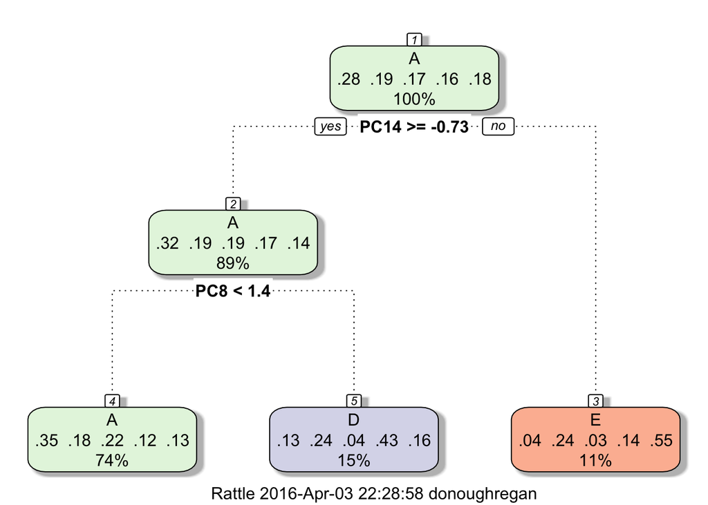

```r
fancyRpartPlot(modFit_rpart$finalModel)
```

## Cross Validation Testing

Now we apply our models to each of the subtesting sets to assess their accuracy.

```r
predict_test_rpart<-predict(modFit_rpart,subtestingPCA)
predict_test_rf<-predict(modFit_rf,subtestingPCA)
predict_test_gbm<-predict(modFit_gbm,subtestingPCA)
```

## Out of sample error

I use the `confusionMatrix` function to measure the out of sample error.

```r
confusionMatrix(predict_test_rpart,subtesting$classe)
```

```
## Confusion Matrix and Statistics
##
##           Reference
## Prediction    A    B    C    D    E
##          A 2062 1057 1269  676  730
##          B    0    0    0    0    0
##          C    0    0    0    0    0
##          D  139  266   59  480  199
##          E   31  195   40  130  513
##
## Overall Statistics
##
##                Accuracy : 0.3894
##                  95% CI : (0.3786, 0.4003)
##     No Information Rate : 0.2845
##     P-Value [Acc > NIR] : < 2.2e-16
##
##                   Kappa : 0.1801
##  Mcnemar's Test P-Value : NA
##
## Statistics by Class:
##
##                      Class: A Class: B Class: C Class: D Class: E
## Sensitivity            0.9238   0.0000   0.0000  0.37325  0.35576
## Specificity            0.3352   1.0000   1.0000  0.89893  0.93816
## Pos Pred Value         0.3559      NaN      NaN  0.41995  0.56436
## Neg Pred Value         0.9172   0.8065   0.8256  0.87976  0.86608
## Prevalence             0.2845   0.1935   0.1744  0.16391  0.18379
## Detection Rate         0.2628   0.0000   0.0000  0.06118  0.06538
## Detection Prevalence   0.7385   0.0000   0.0000  0.14568  0.11586
## Balanced Accuracy      0.6295   0.5000   0.5000  0.63609  0.64696
```

```r
confusionMatrix(predict_test_rf,subtesting$classe)
```

```
## Confusion Matrix and Statistics
##
##           Reference
## Prediction    A    B    C    D    E
##          A 2212   27    3    4    2
##          B    3 1469   26    1    8
##          C    7   21 1323   59   13
##          D   10    0   16 1217   10
##          E    0    1    0    5 1409
##
## Overall Statistics
##
##                Accuracy : 0.9725
##                  95% CI : (0.9686, 0.976)
##     No Information Rate : 0.2845
##     P-Value [Acc > NIR] : < 2.2e-16
##
##                   Kappa : 0.9652
##  Mcnemar's Test P-Value : 2.11e-11
##
## Statistics by Class:
##
##                      Class: A Class: B Class: C Class: D Class: E
## Sensitivity            0.9910   0.9677   0.9671   0.9463   0.9771
## Specificity            0.9936   0.9940   0.9846   0.9945   0.9991
## Pos Pred Value         0.9840   0.9748   0.9297   0.9713   0.9958
## Neg Pred Value         0.9964   0.9923   0.9930   0.9895   0.9949
## Prevalence             0.2845   0.1935   0.1744   0.1639   0.1838
## Detection Rate         0.2819   0.1872   0.1686   0.1551   0.1796
## Detection Prevalence   0.2865   0.1921   0.1814   0.1597   0.1803
## Balanced Accuracy      0.9923   0.9809   0.9758   0.9704   0.9881
```

```r
confusionMatrix(predict_test_gbm,subtesting$classe)
```

```
## Confusion Matrix and Statistics
##
##           Reference
## Prediction    A    B    C    D    E
##          A 1991  173   78   35   35
##          B   41 1124  116   39  104
##          C   82  151 1108  152   98
##          D   98   33   45 1036   62
##          E   20   37   21   24 1143
##
## Overall Statistics
##
##                Accuracy : 0.816
##                  95% CI : (0.8072, 0.8245)
##     No Information Rate : 0.2845
##     P-Value [Acc > NIR] : < 2.2e-16
##
##                   Kappa : 0.767
##  Mcnemar's Test P-Value : < 2.2e-16
##
## Statistics by Class:
##
##                      Class: A Class: B Class: C Class: D Class: E
## Sensitivity            0.8920   0.7404   0.8099   0.8056   0.7926
## Specificity            0.9428   0.9526   0.9254   0.9637   0.9841
## Pos Pred Value         0.8612   0.7893   0.6964   0.8132   0.9181
## Neg Pred Value         0.9565   0.9386   0.9584   0.9620   0.9547
## Prevalence             0.2845   0.1935   0.1744   0.1639   0.1838
## Detection Rate         0.2538   0.1433   0.1412   0.1320   0.1457
## Detection Prevalence   0.2947   0.1815   0.2028   0.1624   0.1587
## Balanced Accuracy      0.9174   0.8465   0.8677   0.8847   0.8884
```

From these it looks like `rpart` is not as good as `gbm` which in turn is not quite as good as random forests. However, there’s a lot of information in these. Instead I pick out the accuracy variable from the previous function. This is an estimate of the out of sample error rate.

```r
Accuracy_rpart<-confusionMatrix(predict_test_rpart,subtesting$classe)$overall['Accuracy']
Accuracy_rf<-confusionMatrix(predict_test_rf,subtesting$classe)$overall['Accuracy']
Accuracy_gbm<-confusionMatrix(predict_test_gbm,subtesting$classe)$overall['Accuracy']
c(Accuracy_rpart,Accuracy_rf,Accuracy_gbm)
```

```
##  Accuracy  Accuracy  Accuracy
## 0.3893704 0.9724700 0.8159572
```

Random forests perform best.

## Application to the final test data set

Using the best model (random forests), the next and final set is to apply it to the test data set. Want to use the same variables as per the training. Then the same PCA combinations as obtained previously when applied to this testing suite.

```r
list_cols<-names(testing) %in% names(subtraining)
testing<-testing[list_cols]
testingPCA<-predict(preProc,testing)
predictions_testset<-predict(modFit_rf,testingPCA,type="class")
predictions_testset
```

```
##  1  2  3  4  5  6  7  8  9 10 11 12 13 14 15 16 17 18 19 20
##  B  A  A  A  A  E  D  B  A  A  B  C  B  A  E  E  A  B  B  B
## Levels: A B C D E
```

## Discussion

The model has been built using data from only 6 participants. Therefore, despite the claim of 97% accuracy of the model, one should take caution that this model has been built from a limited number of participants and therefore may miss some key confounding factors that might show up in a larger sample.

Having applied these predictions to the test data via the course link, I have found a 95% success rate i.e. 19 of the 20 test points were predicted correctly.